# Memo - Examining changes in production in Lost Hills before/during/after SNAPS

2/25/2021

To do: - confirm monitor location - confirm monitoring duration (currently defined as May 1 - July 31, 2019) - do a similar assessment for production wells as I did for the preproduction wells

## Objectives

The California Air Resources Board (CARB) conducted a monitoring campaign in the Kern County community of Lost Hills in 2019 [confirm dates]. A possible concern is that oil and gas operators changed their production activities in response to monitoring. Industry responses to monitoring have been documented in the past, and have been shown to lead to underreporting of pollutant concentrations (Zou 2017). In this memo, I examine whether there were changes in trends in oil/gas preproduction and production activities in oil fields in Lost Hills before, during, and after the SNAPS monitoring campaign.

According to the [SNAPS Lost Hills Air Monitoring Plan](https://ww2.arb.ca.gov/resources/documents/lost-hills-air-monitoring-plan-snaps), monitoring was scheduled to begin in April 2019 and proceed for 3 months, with options for extension. Some pollutants were continuously montored, others were monitored on a 1-in-6 day schedule.

## Analysis

I haven’t had time to confirm the location of the monitoring site, but I think it was near the Lost Hills school district building. From Google Maps, the coordinates are: 35.615175, -119.700624

### Preproduction wells

#### Plot. Wells spudd by month, Lost Hills

[output not shown]

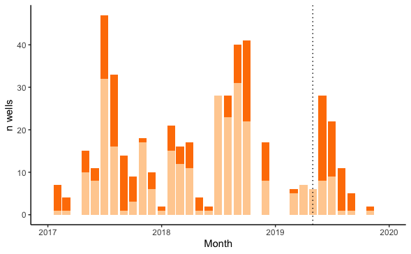

#### Plot. Wells spudd by month, Kern County (excluding Lost Hills)

[output not shown]

[output cut: 23 more lines]

[output not shown]

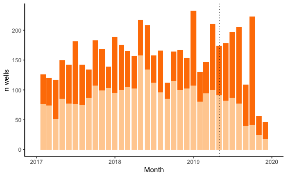

#### Map. Location of preproduction wells near Lost Hills monitoring site

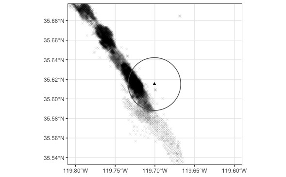

#### Map. Location of preproduction wells in 2017-19

*Note: Wells drilled during monitoring period are in red*

Monitor - triangle Monitor buffer - 3 km

[figure not shown]

#### Map. Location of preproduction wells in 2019

*Note: Wells drilled during monitoring period are in red*

[figure not shown]

It appears that, during the monitoring period, the locations of wells that were in preproduction (spudding or completion) were located to the west/southwest, where the wind was least likely to be blowing from. WElls drilled to the northwest, where the prevailing wind was coming from during the monitoring period, were drilled outside the monitoring period. Arguably, any of these wells could have been drilled before/after April 2019.

#### Plot. Wind rose by season in 2019, Kern County

*Note: This data comes from 1999-2019 AQS monitors exposure data, not specific to Lost Hills but trends should hold for Kern County*

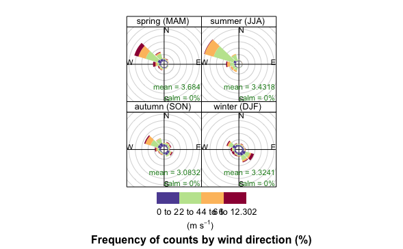

```
openair object created by:
    windRose(mydata = subset(aqs_daily_annuli_exposure_kern, year ==     2019), type = "season", paddle = FALSE, angle.scale = NA)

this contains:
Unknown or uninitialised column: `subsets`. a single data frame:
    $data [with no subset structure]
    a single plot object:
    $plot [with no subset structure]
```

[figure not shown]

In 2019 in Kern County, the wind was predominantly blowing from the northwest during the monitoring period inspring and summer; the wind blew from the west, where preproduction was occuring, approximately 15% of the time durng spring and summer.